# Incidents of Larceny-Theft in San Francisco (2003-2014)

```python
from IPython.display import Image
Image(url= "https://images.squarespace-cdn.com/content/v1/5452d441e4b0c188b51fef1a/1433027071399-PM7KLRE8MLWCEI7W7AK6/image-asset.jpeg"
,width=500, height=300)
```

[figure not shown]

> Ming Zhao  
> Prof. James Sharpnack  
> STA 141B  
> June 6, 2021

## Introduction

San Francisco is one of the most popular tourist destinations in the world and considered as a desired place to live in with its pleasant climate, progressive culture, and career opportunities. However, what is the downside of visiting or residing in SF?

I look at SF crime reports from 2003 to 2014, with a focus on the incidents of Larceny-Theft. I am interested in how the incident changes with time and district as well as how weather and unemployment influence the frequency of the incident.

The primary dataset I rely on is downloaded from Kaggle, https://www.kaggle.com/c/sf-crime/data, which includes the type, time, result, district, latitude, and longitude of the crime incidents derived from the SFPD Crime Incident Reporting System. The original crime data ranges from 1/1/2003 to 5/13/2015 and is divided into a training set and a test set, in which weeks of even number belong to the training and weeks of odd number belong to the test.

For this analysis, I only use the training set. Additionally, I exclude the data of 2015 for the purpose of exploring the crime incidents over month within a year. I also remove the observations out of the range of latitude and longitude of SF.

Furthermore, to examine the effect of unemployment rate and weather on crime incidents, I downloded the monthly unemployment data by U.S. Bureau of Labor Statistics from Economic Research and scraped the daily weather data from Weather Underground API.

### Contents

- Data Preprocessing
  1. Crime data
  2. Unemployment data
  3. Weather data
- Exploratory Data Analysis
  1. Crime and Time
  2. Crime and District
  3. Crime and Unemployment
  4. Crime and Temperature
- Model Training and Forcasting
  1. Time Series Regression
  2. ARIMA
  3. SARIMA
  4. SARIMAX
- Conclusion

```python
import sys, os
sys.path.append('../code')
```

```python
import pandas as pd
import numpy as np
import seaborn as sns
import matplotlib
import matplotlib.pyplot as plt
import plotnine as p9
import statsmodels.formula.api as smf
import requests
import sqlalchemy as sqla
from sqlalchemy import create_engine
from sklearn.preprocessing import LabelEncoder
```

```python
from statsmodels.tsa.stattools import adfuller
from statsmodels.tsa.stattools import acf
from statsmodels.graphics.tsaplots import plot_pacf
from statsmodels.graphics.tsaplots import plot_acf
from statsmodels.tsa.seasonal import seasonal_decompose
from statsmodels.tsa.arima_model import ARIMA
from statsmodels.tsa.statespace.sarimax import SARIMAX
from scipy import stats
import pmdarima as pm
```

```python
from weather_data_scraping import scrap_date_range
from diagnostics import diagnostic_plots
from forecast_metrics import forecast_accuracy
```

```python
%matplotlib inline
import warnings
warnings.filterwarnings("ignore")
```

## Data Preprocessing

### Crime data

```python
df = pd.read_csv("../data/train.csv.zip")
```

```python
df.Dates=pd.to_datetime(df.Dates)
```

```python
print('{} samples that are not Larceny-Theft were excluded'.format(sum(df.Category != 'LARCENY/THEFT')))
df = df[df['Category'] == 'LARCENY/THEFT']
```

```
703149 samples that are not Larceny-Theft were excluded
```

```python
print('{} samples from 2015 were excluded'.format(sum((df['Dates'] >= '2015-01-1'))))
df = df.loc[(df['Dates'] >= '2003-01-01') & (df['Dates'] < '2015-01-1')]
```

```
7511 samples from 2015 were excluded
```

```python
print('{} samples out of SF were excluded'.format(sum(df.Y == 90)))
df = df[df['Y'] < 90]
```

```
15 samples out of SF were excluded
```

```python
df.info()
```

```
<class 'pandas.core.frame.DataFrame'>
Int64Index: 167374 entries, 27584 to 878046
Data columns (total 9 columns):
 #   Column      Non-Null Count   Dtype
---  ------      --------------   -----
 0   Dates       167374 non-null  datetime64[ns]
 1   Category    167374 non-null  object
 2   Descript    167374 non-null  object
 3   DayOfWeek   167374 non-null  object
 4   PdDistrict  167374 non-null  object
 5   Resolution  167374 non-null  object
 6   Address     167374 non-null  object
 7   X           167374 non-null  float64
 8   Y           167374 non-null  float64
dtypes: datetime64[ns](1), float64(2), object(6)
memory usage: 12.8+ MB
```

```python
df.head()
```

|  | Dates | Category | Descript | DayOfWeek | PdDistrict | Resolution | Address | X | Y |
| --- | --- | --- | --- | --- | --- | --- | --- | --- | --- |
| 27584 | 2014-12-28 23:30:00 | LARCENY/THEFT | GRAND THEFT PICKPOCKET | Sunday | MISSION | NONE | 4100 Block of 18TH ST | -122.435563 | 37.760801 |
| 27585 | 2014-12-28 23:30:00 | LARCENY/THEFT | GRAND THEFT FROM LOCKED AUTO | Sunday | NORTHERN | NONE | 1900 Block of LOMBARD ST | -122.433575 | 37.800037 |
| 27593 | 2014-12-28 23:00:00 | LARCENY/THEFT | GRAND THEFT FROM LOCKED AUTO | Sunday | CENTRAL | NONE | POST ST / JONES ST | -122.413358 | 37.787664 |
| 27594 | 2014-12-28 23:00:00 | LARCENY/THEFT | GRAND THEFT FROM LOCKED AUTO | Sunday | SOUTHERN | NONE | HOWARD ST / 8TH ST | -122.411610 | 37.776221 |
| 27595 | 2014-12-28 23:00:00 | LARCENY/THEFT | GRAND THEFT FROM LOCKED AUTO | Sunday | CENTRAL | NONE | BUSH ST / STOCKTON ST | -122.407152 | 37.790366 |

```python
df.Dates.describe()
```

```
count                  167374
unique                 109572
top       2011-01-01 00:01:00
freq                       17
first     2003-01-06 00:01:00
last      2014-12-28 23:30:00
Name: Dates, dtype: object
```

### Unemployment data

```python
df_ue = pd.read_csv('../data/unemployment.csv')
```

```python
df_ue = df_ue.rename(columns={'DATE':'date', 'CASANF0URN':'unemployment_rate'})
```

```python
df_ue.date = pd.to_datetime(df_ue.date)
```

```python
df_ue = df_ue.loc[(df_ue['date'] >= '2003-01-01') & (df_ue['date'] < '2015-01-1')]
```

```python
df_ue.shape
```

```
(144, 2)
```

```python
df_ue.head()
```

|  | date | unemployment_rate |
| --- | --- | --- |
| 156 | 2003-01-01 | 7.2 |
| 157 | 2003-02-01 | 7.0 |
| 158 | 2003-03-01 | 7.1 |
| 159 | 2003-04-01 | 6.8 |
| 160 | 2003-05-01 | 6.7 |

### Weather data

```python
weather_data_path = '../data/sf_weather.csv'
if not os.path.exists(weather_data_path):
    scrap_date_range('2003-01-01','2014-12-31', weather_data_path)
```

```python
df_wx = pd.read_csv(weather_data_path)
```

```python
df_wx.date = pd.to_datetime(df_wx.date)
```

```python
df_wx.shape
```

```
(4383, 3)
```

```python
df_wx.head()
```

|  | date | temp | precip |
| --- | --- | --- | --- |
| 0 | 2003-01-01 | 8.958333 | 0 |
| 1 | 2003-01-02 | 10.166667 | 0 |
| 2 | 2003-01-03 | 10.400000 | 0 |
| 3 | 2003-01-04 | 11.500000 | 0 |
| 4 | 2003-01-05 | 11.128205 | 0 |

## Exploratory Data Analysis

### 1. Crime and Time

```python
disk_engine = sqla.create_engine('sqlite:///crime.sqlite')
df.to_sql('crime', con=disk_engine, if_exists='replace')
```

```python
sql_query = """
SELECT round(avg(Count)) as avg_yearly_count
  FROM
    (
    SELECT count(Dates) AS Count
    FROM crime
    GROUP BY strftime('%Y',Dates)
    )
"""
avg_yearly_count = pd.read_sql_query(sql_query, disk_engine, parse_dates='date')
avg_yearly_count
```

|  | avg_yearly_count |
| --- | --- |
| 0 | 13948.0 |

```python
sql_query = """
SELECT round(avg(Count)) as avg_monthly_count
  FROM
    (
    SELECT count(Dates) AS Count
    FROM crime
    GROUP BY strftime('%Y',Dates), strftime('%m',Dates)
    )
"""
avg_monthly_count = pd.read_sql_query(sql_query, disk_engine, parse_dates='date')
avg_monthly_count
```

|  | avg_monthly_count |
| --- | --- |
| 0 | 1162.0 |

```python
sql_query = """
SELECT round(avg(Count)) as avg_daily_count
  FROM
    (
    SELECT count(Dates) AS Count
    FROM crime
    GROUP BY strftime('%Y',Dates), strftime('%m',Dates), strftime('%d',Dates)
    )
"""
avg_daily_count = pd.read_sql_query(sql_query, disk_engine, parse_dates='date')
avg_daily_count
```

|  | avg_daily_count |
| --- | --- |
| 0 | 77.0 |

```python
print('The average number of yearly Larceny-Theft incidents is {}.'.format(2*avg_yearly_count.iloc[0,0]))
print('The average number of monthly Larceny-Theft incidents is {}.'.format(2*avg_monthly_count.iloc[0,0]))
print('The average number of daily Larceny-Theft incidents is {}.'.format(2*avg_daily_count.iloc[0,0]))
```

```
The average number of yearly Larceny-Theft incidents is 27896.0.
The average number of monthly Larceny-Theft incidents is 2324.0.
The average number of daily Larceny-Theft incidents is 154.0.
```

```python
df['year'] = df.Dates.dt.year
df['month'] = df.Dates.dt.month
df['day'] = df.Dates.dt.day
df['hour'] = df.Dates.dt.hour
```

```python
data = df.copy()
```

```python
df_year_g = df.groupby(['year'], as_index=False).agg({'Dates':'count'}). \
            rename(columns={'Dates': 'count'})
```

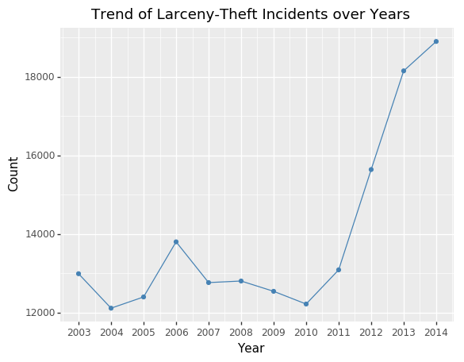

```python
gg = p9.ggplot(df_year_g)
gg += p9.aes(x='year',y='count')
gg += p9.geom_line(color="steelblue")
gg += p9.geom_point(color="steelblue")
gg += p9.labels.ggtitle('Trend of Larceny-Theft Incidents over Years')
gg += p9.xlab('Year') + p9.ylab('Count')
gg += p9.scale_x_continuous(breaks=range(2003,2015,1))
gg
```

```python
df_month_g = df.groupby(['month'], as_index=False).agg({'Dates':'count'}). \
             rename(columns={'Dates': 'count'})
```

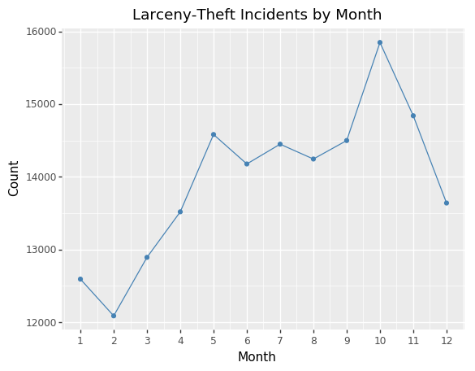

```python
gg = p9.ggplot(df_month_g)
gg += p9.aes(x='month', y='count')
gg += p9.geom_line(color="steelblue")
gg += p9.geom_point(color="steelblue")
gg += p9.labels.ggtitle('Larceny-Theft Incidents by Month')
gg += p9.xlab('Month') + p9.ylab('Count')
gg += p9.scale_x_continuous(breaks=range(1,13,1))
gg
```

```python
df_dow_g = df.groupby(df['DayOfWeek'], as_index=False).agg({'Dates':'count'}). \
           rename(columns={'Dates': 'count'})
```

```python
dow_list = ['Monday','Tuesday','Wednesday','Thursday','Friday','Saturday','Sunday']
dow = pd.Categorical(df_dow_g['DayOfWeek'], categories=dow_list)
df_dow_g = df_dow_g.assign(DayOfWeek = dow)
```

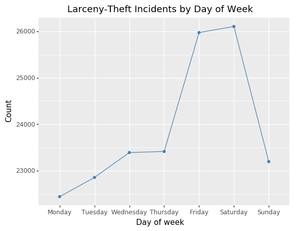

```python
gg = p9.ggplot(df_dow_g)
gg += p9.aes(x='DayOfWeek', y='count', group=1)
gg += p9.geom_line(color="steelblue")
gg += p9.geom_point(color="steelblue")
gg += p9.labels.ggtitle('Larceny-Theft Incidents by Day of Week')
gg += p9.xlab('Day of week') + p9.ylab('Count')
gg
```

```python
df['night'] = np.where((df.Dates.dt.hour >= 20) | (df.Dates.dt.hour < 8), 1, 0)
night=df.night.mean() * 100
print("The ratio of Larceny-Theft reports at night: {} %".format(round(night,2)))
```

```
The ratio of Larceny-Theft reports at night: 35.51 %
```

```python
condlist = [((df.Dates.dt.hour>=5)&(df.Dates.dt.hour<12)),
            ((df.Dates.dt.hour>=12)&(df.Dates.dt.hour<18)),
            ((df.Dates.dt.hour>=18)&(df.Dates.dt.hour<22)),
            ((df.Dates.dt.hour>=22)|(df.Dates.dt.hour<5))
           ]

selectlist = ['Morning', 'Afternoon', 'Evening', 'Night']
```

```python
df['time_shift'] = np.select(condlist, selectlist)
```

```python
df_ts_g = df.groupby(df['time_shift'], as_index=False).agg({'Dates':'count'}). \
           rename(columns={'Dates': 'count'})
```

```python
ts_list = ['Morning','Afternoon','Evening','Night']
ts = pd.Categorical(df_ts_g['time_shift'], categories=ts_list)
df_ts_g = df_ts_g.assign(time_shift = ts)
```

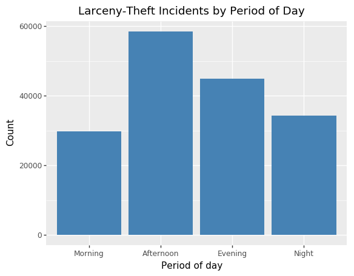

```python
gg = p9.ggplot(df_ts_g)
gg += p9.aes(x='time_shift', y='count')
gg += p9.geom_bar(stat="identity", fill="steelblue")
gg += p9.labels.ggtitle('Larceny-Theft Incidents by Period of Day')
gg += p9.xlab('Period of day') + p9.ylab('Count')
gg
```

```python
df_hr_g = df.groupby(df['hour'], as_index=False).agg({'Dates':'count'}). \
           rename(columns={'Dates': 'count'})
```

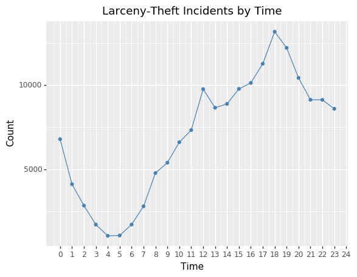

```python
gg = p9.ggplot(df_hr_g)
gg += p9.aes(x='hour', y='count')
gg += p9.geom_line(color="steelblue")
gg += p9.geom_point(color="steelblue")
gg += p9.labels.ggtitle('Larceny-Theft Incidents by Time')
gg += p9.xlab('Time') + p9.ylab('Count')
gg += p9.scale_x_continuous(breaks=range(0,25,1))
gg
```

### 2. Crime and District

```python
set(df['PdDistrict'])
```

```
{'BAYVIEW',
 'CENTRAL',
 'INGLESIDE',
 'MISSION',
 'NORTHERN',
 'PARK',
 'RICHMOND',
 'SOUTHERN',
 'TARAVAL',
 'TENDERLOIN'}
```

```python
len(set(df['PdDistrict']))
```

```
10
```

```python
df['PdDistrict'].value_counts()
```

```
SOUTHERN      39914
NORTHERN      27258
CENTRAL       23862
MISSION       17817
TARAVAL       11366
INGLESIDE      9872
BAYVIEW        9700
TENDERLOIN     9509
RICHMOND       9322
PARK           8754
Name: PdDistrict, dtype: int64
```

```python
district_list = df['PdDistrict'].value_counts().index.tolist()
district = pd.Categorical(df['PdDistrict'], categories=district_list)
df_district = df.assign(PdDistrict = district)
df_district = df_district.dropna(subset=['PdDistrict'])
```

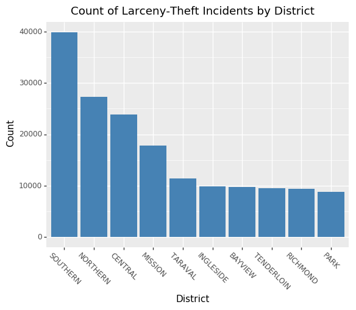

```python
gg = p9.ggplot(df_district)
gg += p9.aes(x='PdDistrict')
gg += p9.geom_bar(fill="steelblue")
gg += p9.labels.ggtitle('Count of Larceny-Theft Incidents by District')
gg += p9.xlab('District') + p9.ylab('Count')
gg += p9.theme(axis_text_x = p9.element_text(angle=-45))
gg
```

```python
df_g_loc_year = df.groupby(['PdDistrict', 'year'], as_index=False).agg({'X':'count'}). \
           rename(columns={'X': 'count'})
```

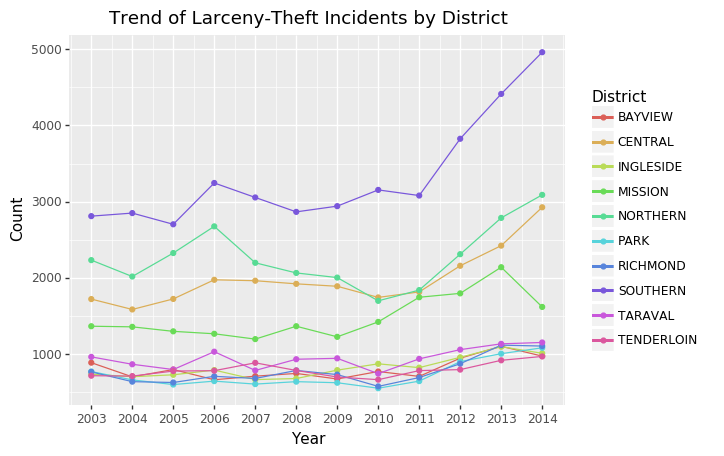

```python
gg = p9.ggplot(df_g_loc_year)
gg += p9.aes(x='year',y='count',color='PdDistrict')
gg += p9.geom_line()
gg += p9.geom_point()
gg += p9.scale_x_continuous(limits=(2003, 2014),breaks=range(2003, 2015, 1))
gg += p9.labs(x="Year", y="Count", color="District")
gg += p9.labels.ggtitle('Trend of Larceny-Theft Incidents by District')
gg
```

### 3. Crime and Unemployment

```python
df_ue['date']=df_ue['date'].astype(str)
```

```python
df_g_date = df.groupby(['year','month'], as_index=False).agg({'X':'count'}). \
           rename(columns={'X': 'count'})
```

```python
df_g_date['date'] = df_g_date.year.astype('str') + '-' + df_g_date.month.astype('str').str.zfill(2) + '-01'
```

```python
df_merge_ue = df_g_date.merge(df_ue, on='date', how='left').sort_values('date')
```

```python
df_merge_ue['date'] = df_merge_ue['date'].astype('datetime64[ns]')
```

```python
df_ue_plot = df_merge_ue[['date', 'count', 'unemployment_rate']]

df_ue_plot['MA_rate'] = df_ue_plot['unemployment_rate'].rolling(window=6).mean()
df_ue_plot['MA_count'] = df_ue_plot['count'].rolling(window=6).mean()

to_drop = ['count','unemployment_rate']
df_ue_plot = df_ue_plot.drop(to_drop, axis=1)
```

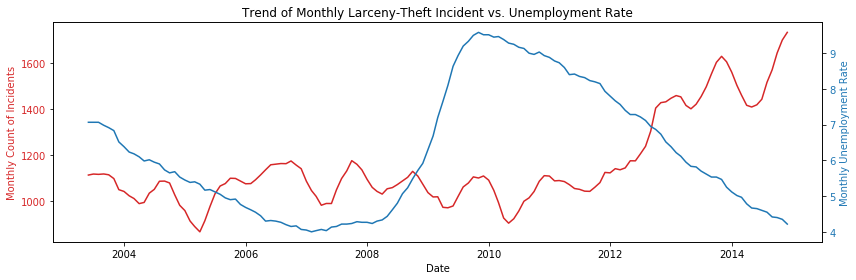

```python
fig, ax1 = plt.subplots(figsize=(12,4))

font = {'fontsize' : 12}
plt.title('Trend of Monthly Larceny-Theft Incident vs. Unemployment Rate', fontdict = font)

color = 'tab:red'
ax1.set_xlabel('Date')
ax1.set_ylabel('Monthly Count of Incidents', color=color)
ax1.plot(df_ue_plot.date, df_ue_plot.MA_count, color=color)
ax1.tick_params(axis='y', labelcolor=color)

ax2 = ax1.twinx()  # instantiate a second axes that shares the same x-axis

color = 'tab:blue'
ax2.set_ylabel('Monthly Unemployment Rate', color=color)  # already handled the x-label with ax1
ax2.plot(df_ue_plot.date, df_ue_plot.MA_rate, color=color)
ax2.tick_params(axis='y', labelcolor=color)

fig.tight_layout()  # otherwise the right y-label is slightly clipped
plt.show()
```

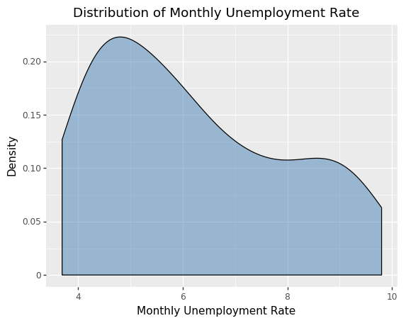

```python
gg = p9.ggplot(df_merge_ue)
gg += p9.aes(x='unemployment_rate')
gg += p9.geom_density(alpha=.5,fill="steelblue")
gg += p9.labels.ggtitle('Distribution of Monthly Unemployment Rate')
gg += p9.xlab('Monthly Unemployment Rate') + p9.ylab('Density')
gg
```

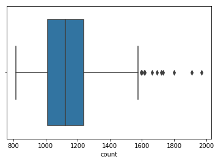

```python
sns.boxplot(df_merge_ue['count'])
plt.show()
```

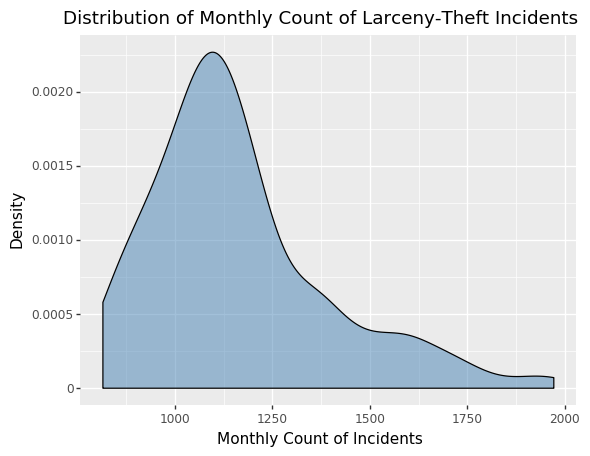

```python
gg = p9.ggplot(df_merge_ue)
gg += p9.aes(x='count')
gg += p9.geom_density(alpha=.5,fill="steelblue")
gg += p9.labels.ggtitle('Distribution of Monthly Count of Larceny-Theft Incidents')
gg += p9.xlab('Monthly Count of Incidents') + p9.ylab('Density')
gg
```

```python
df_merge_ue['log_count'] = np.log(df_merge_ue['count'])
```

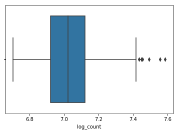

```python
sns.boxplot(df_merge_ue['log_count'])
plt.show()
```

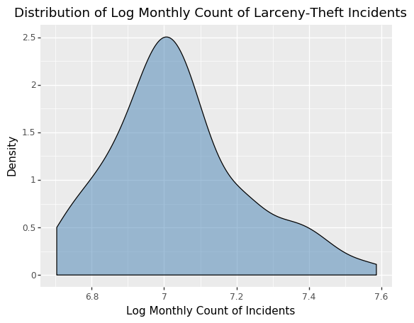

```python
gg = p9.ggplot(df_merge_ue)
gg += p9.aes(x='log_count')
gg += p9.geom_density(alpha=.5,fill="steelblue")
gg += p9.labels.ggtitle('Distribution of Log Monthly Count of Larceny-Theft Incidents')
gg += p9.xlab('Log Monthly Count of Incidents') + p9.ylab('Density')
gg
```

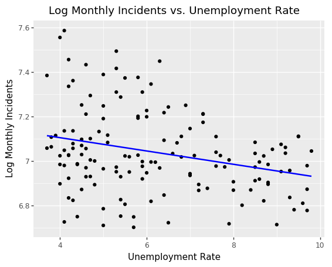

```python
gg = p9.ggplot(df_merge_ue)
gg += p9.aes(x='unemployment_rate',y='log_count')
gg += p9.geom_point()
gg += p9.stat_smooth(mapping=p9.aes(x='unemployment_rate',y='log_count'),
                 method='lm', se = False, inherit_aes=False,color='blue')
gg += p9.labels.ggtitle('Log Monthly Incidents vs. Unemployment Rate')
gg += p9.xlab('Unemployment Rate') + p9.ylab('Log Monthly Incidents')
gg
```

```python
model_ue = smf.ols(formula='log_count ~ unemployment_rate', data=df_merge_ue)
results = model_ue.fit()
```

```python
print(results.summary())
```

```
                            OLS Regression Results
==============================================================================
Dep. Variable:              log_count   R-squared:                       0.081
Model:                            OLS   Adj. R-squared:                  0.075
Method:                 Least Squares   F-statistic:                     12.53
Date:                Sun, 10 Oct 2021   Prob (F-statistic):           0.000541
Time:                        11:45:53   Log-Likelihood:                 43.244
No. Observations:                 144   AIC:                            -82.49
Df Residuals:                     142   BIC:                            -76.55
Df Model:                           1
Covariance Type:            nonrobust
=====================================================================================
                        coef    std err          t      P>|t|      [0.025      0.975]
-------------------------------------------------------------------------------------
Intercept             7.2253      0.054    132.711      0.000       7.118       7.333
unemployment_rate    -0.0299      0.008     -3.540      0.001      -0.047      -0.013
==============================================================================
Omnibus:                        3.361   Durbin-Watson:                   0.340
Prob(Omnibus):                  0.186   Jarque-Bera (JB):                3.293
Skew:                           0.367   Prob(JB):                        0.193
Kurtosis:                       2.906   Cond. No.                         23.9
==============================================================================

Notes:
[1] Standard Errors assume that the covariance matrix of the errors is correctly specified.
```

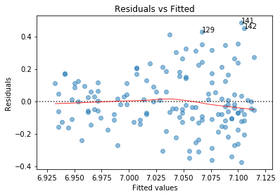

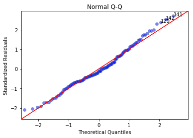

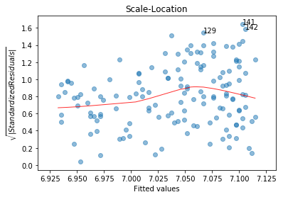

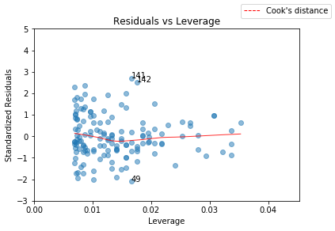

```python
diagnostic_plots(df_merge_ue['unemployment_rate'], df_merge_ue['log_count'])
```

### 4. Crime and Temperature

```python
df.Dates=pd.to_datetime(df.Dates).dt.date
```

```python
df['Dates']=df['Dates'].astype(str)
df_wx['date']=df_wx['date'].astype(str)
```

```python
df_g_date = df.groupby('Dates', as_index=False).agg({'X':'count'}). \
            rename(columns={'Dates': 'date', 'X': 'count'})
```

```python
df_merge_wx = df_g_date.merge(df_wx, on='date', how='left').sort_values('date')
```

```python
df_merge_wx['date'] = df_merge_wx['date'].astype('datetime64[ns]')
```

```python
df_wx_plot = df_merge_wx[['date', 'count', 'temp']]

df_wx_plot['MA_temp'] = df_wx_plot['temp'].rolling(window=90).mean()
df_wx_plot['MA_count'] = df_wx_plot['count'].rolling(window=90).mean()

to_drop = ['count','temp']
df_wx_plot = df_wx_plot.drop(to_drop, axis=1)
```

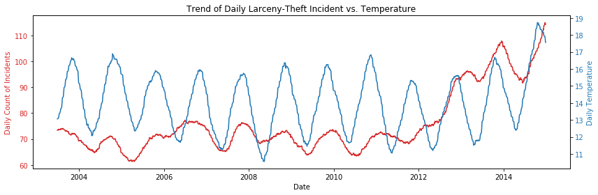

```python
fig, ax1 = plt.subplots(figsize=(12,4))

font = {'fontsize' : 12}
plt.title('Trend of Daily Larceny-Theft Incident vs. Temperature', fontdict = font)

color = 'tab:red'
ax1.set_xlabel('Date')
ax1.set_ylabel('Daily Count of Incidents', color=color)
ax1.plot(df_wx_plot.date, df_wx_plot.MA_count, color=color)
ax1.tick_params(axis='y', labelcolor=color)

ax2 = ax1.twinx()  # instantiate a second axes that shares the same x-axis

color = 'tab:blue'
ax2.set_ylabel('Daily Temperature', color=color)  # already handled the x-label with ax1
ax2.plot(df_wx_plot.date, df_wx_plot.MA_temp, color=color)
ax2.tick_params(axis='y', labelcolor=color)

fig.tight_layout()  # otherwise the right y-label is slightly clipped
plt.show()
```

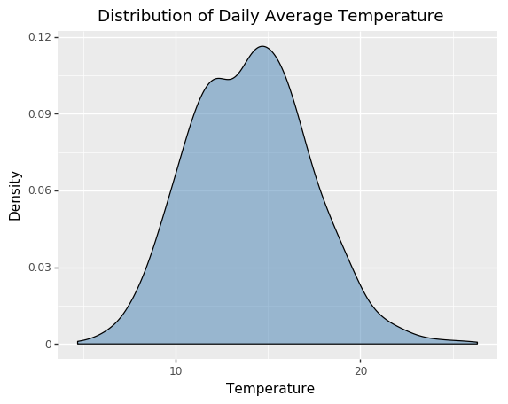

```python
gg = p9.ggplot(df_merge_wx)
gg += p9.aes(x='temp')
gg += p9.geom_density(alpha=.5,fill="steelblue")
gg += p9.labels.ggtitle('Distribution of Daily Average Temperature')
gg += p9.xlab('Temperature') + p9.ylab('Density')
gg
```

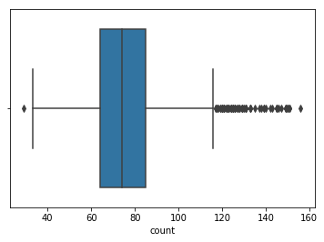

```python
sns.boxplot(df_merge_wx['count'])
plt.show()
```

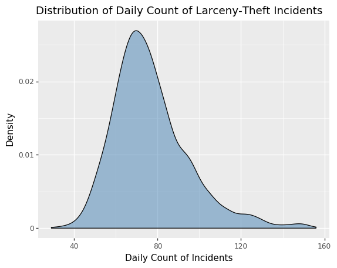

```python
gg = p9.ggplot(df_merge_wx)
gg += p9.aes(x='count')
gg += p9.geom_density(alpha=.5,fill="steelblue")
gg += p9.labels.ggtitle('Distribution of Daily Count of Larceny-Theft Incidents')
gg += p9.xlab('Daily Count of Incidents') + p9.ylab('Density')
gg
```

```python
df_merge_wx['log_count'] = np.log(df_merge_wx['count'])
```

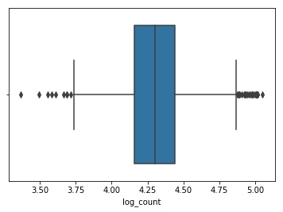

```python
sns.boxplot(df_merge_wx['log_count'])
plt.show()
```

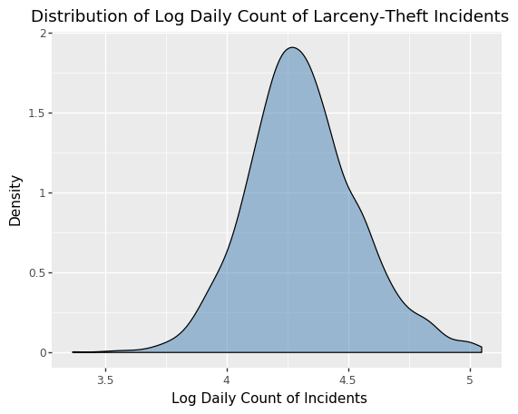

```python
gg = p9.ggplot(df_merge_wx)
gg += p9.aes(x='log_count')
gg += p9.geom_density(alpha=.5,fill="steelblue")
gg += p9.labels.ggtitle('Distribution of Log Daily Count of Larceny-Theft Incidents')
gg += p9.xlab('Log Daily Count of Incidents') + p9.ylab('Density')
gg
```

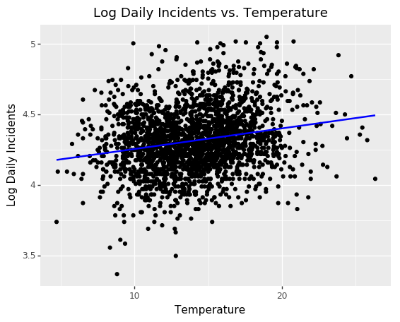

```python
gg = p9.ggplot(df_merge_wx)
gg += p9.aes(x='temp',y='log_count')
gg += p9.geom_point()
gg += p9.stat_smooth(mapping=p9.aes(x='temp',y='log_count'),
                 method='lm', se = False, inherit_aes=False,color='blue')
gg += p9.labels.ggtitle('Log Daily Incidents vs. Temperature')
gg += p9.xlab('Temperature') + p9.ylab('Log Daily Incidents')
gg
```

```python
model_wx = smf.ols(formula='log_count ~ temp', data=df_merge_wx)
results = model_wx.fit()
```

```python
print(results.summary())
```

```
                            OLS Regression Results
==============================================================================
Dep. Variable:              log_count   R-squared:                       0.043
Model:                            OLS   Adj. R-squared:                  0.043
Method:                 Least Squares   F-statistic:                     98.85
Date:                Sun, 10 Oct 2021   Prob (F-statistic):           8.25e-23
Time:                        11:46:19   Log-Likelihood:                 188.49
No. Observations:                2182   AIC:                            -373.0
Df Residuals:                    2180   BIC:                            -361.6
Df Model:                           1
Covariance Type:            nonrobust
==============================================================================
                 coef    std err          t      P>|t|      [0.025      0.975]
------------------------------------------------------------------------------
Intercept      4.1085      0.021    193.949      0.000       4.067       4.150
temp           0.0146      0.001      9.943      0.000       0.012       0.018
==============================================================================
Omnibus:                       21.868   Durbin-Watson:                   0.842
Prob(Omnibus):                  0.000   Jarque-Bera (JB):               23.302
Skew:                           0.210   Prob(JB):                     8.71e-06
Kurtosis:                       3.282   Cond. No.                         64.5
==============================================================================

Notes:
[1] Standard Errors assume that the covariance matrix of the errors is correctly specified.
```

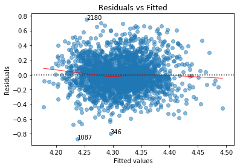

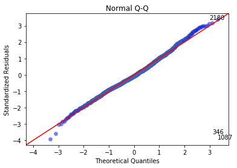

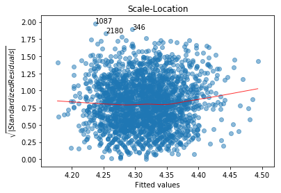

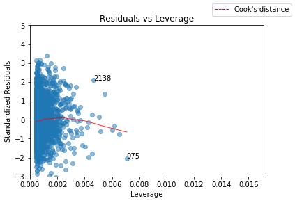

```python
diagnostic_plots(df_merge_wx['temp'], df_merge_wx['log_count'])
```